# WQD 7004 GROUP PROJECT

Group 3 (Teoh Xu Hao, Chow Hui Ting, Pang Woon Yen)

06/06/2021

## Multiple Linear Regression for the Prediction of House Prices

### Introduction

#### Overview

**Introduction**

House price floating every now and then. It became difficult to estimate the house price, especially during the pandemic.

Regression models are powerful models to describe relationships between variables. We can observe the changes of dependent variables when independent variables change. Multiple Linear Regression (MLR) estimates the relationship between two or more independent variables and one dependent variable. Analysis of Variance (ANOVA) is a subset of MLR. ANOVA estimates how a quantitative dependent variable varies base on the levels of categorical independent variables.

This project focuses on exploring the house sales dataset, using regression models to examine the relationship between variables of the dataset and estimate the future house price.

**Problem Statement**

House price varies based on the condition of itself and the environment. From the number of bedrooms to the location of the house, any variable might be the key that affects the house price the most. This project will use ANOVA and MLR to determine the relation of house situations with sold price and predict the house price.

**Idendified Questions**

1. Is there a significant difference in the house sold price based on the house variables?
2. Can we predict the house price with the given attributes of each record of house sold?

**Objectives**

1. To have a basic understanding of the dataset.
2. To investigate if the condition rate, renovation and city located affect house sold price.
3. To predict the future house price with at least 70% of accuracy.

#### Dataset Information

**The table below contains basic information of the dataset:**

[output not shown]

**The table below describes the 21 variables of the raw dataset:**

| No. | Variable | Description | Datatype |
| --- | --- | --- | --- |
| 1 | id | - | Numeric |
| 2 | date | Date of house was sold | String |
| 3 | price | Price sold | Numeric |
| 4 | bedrooms | Number of bedroom | Numeric |
| 5 | bathrooms | Number of bathroom per bedroom | Numeric |
| 6 | sqft_living | House square footage | Numeric |
| 7 | sqft_lot | Lot square footage | Numeric |
| 8 | floors | Floor level | Numeric |
| 9 | waterfront | House has a view to a waterfront | Numeric |
| 10 | view | House has been viewed | Numeric |
| 11 | condition | How good the house condition is: 1=poor; 5=excellent | Numeric |
| 12 | grade | Grade given by King County: 1=poor; 5=excellent | Numeric |
| 13 | sqft_above | Square footage of house apart from basement | Numeric |
| 14 | sqrt_basement | Basement square footage | Numeric |
| 15 | yr_built | House built year | Numeric |
| 16 | yr_renovated | House renovated year | Numeric |
| 17 | zipcode | House zip code | Numeric |
| 18 | lat | House latitude coordinate | Numeric |
| 19 | long | House longitude coordinate | Numeric |
| 20 | sqft_living15 | Living room area in 2015 (implies renovated) | Numeric |
| 21 | sqft_loft15 | Lot area in 2015 (implies renovated) | Numeric |

### Methodology

There are 3 methods being carried out on the dataset to achieve our main objectives.

#### Exploratory Data Analysis (EDA)

Exploratory Data Analysis, also known as data exploration, is the first step in a data analysis to explore the nature of data by doing some **visualisations**. EDA is a quick and simple analysis where it could help to **determine the underlying pattern, detect outliers or anomalies, and to understand the relationships between variables and hence enable us to extract important factors for the model we are going to build**.  
**Plotting from raw data** allows us to have an overview on the behaviours and the distributions of variables. For instance, histogram could be used to visualise the distribution of a numerical variable whereas a bar chart could be used to visualise the frequency distribution of a categorical variable.  
Box plot could be used to detect outliers for single numerical variable, whereas a scatter plot is able to detect an outlier observation between two numerical variables. Other than that, a scatter plot is also good to visualise the relationship or correlation between two variables. Consequently, we are able to detect the important factors which correlated with the dependent variable that we would want to predict.  
R package of *tidyverse* is good for data subsetting, data transforming and data visualisation. The package *ggplot2* is especially useful for EDA when it comes to visualisation, such as histogram, bar chart, box plot etc could be easily done by using ggplot function.  
Example of coding for a simple boxplot:

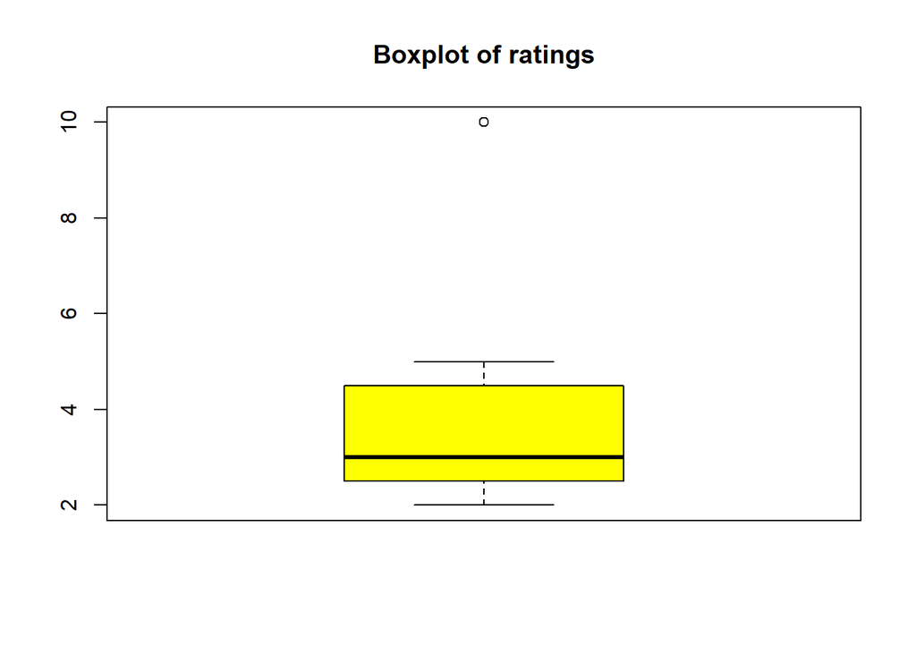

```r
rating <- c(5,2,3,2,4,3,10)
boxplot(rating, col="yellow")
title("Boxplot of ratings")
```

```r
#There is an outlier in the rating data series.
```

#### Analysis of Variance (ANOVA)

Analysis of variance (ANOVA) is a method used to test if there is significant difference in the means of two or more independent groups or levels of factors. It is categorised into one way ANOVA and two way ANOVA - one way ANOVA is to conduct a hypothesis testing on one independent variable whereas two way ANOVA will involve two or more independent variables.  
The hypothesis testing for ANOVA could be generally mentioned as:  
$H_{0}$ (Null Hypothesis): There is no difference in means among the independent groups of object.  
$H_{1}$ (Alternative Hypothesis): There are at least two independent groups having means which are statistically different from each other.  
The null hypothesis could be expressed in the format of symbol:  
$H_{0}: \mu_{1} = \mu_{2} = \mu_{3} = ... = \mu_{k}$  
where $\mu =$ group mean  
$k =$ number of independent groups  
The test statistic for ANOVA is F-statistic and it is following F-distribution:  
$F = \frac{\sum n_{j}(\bar{X_{j}}-\bar{X})^{2}/(k-1)}{\sum\sum(X-\bar{X_{j}})^{2}/(N-k)}$  
with the critical value to be found in the table of probability values of F-distribution with degrees of freedom $df_{1} = k-1$ and $df_{2} = N-k$ where $N = n_{1} + n_{2} + ... + n_{k}$. The F-test is also called as Omnibus Test.  
However, there are some assumptions to be taken care of before carrying out the ANOVA test:  
1. The population from which the sample is drawn is normally distributed.  
2. Homogeneity of variance among the groups of independent variable - the variance for each group of samples are approximately the same.  
3. All the observations in samples should be independent from each other.  
If the F-statistic is large enough to reject the null hypothesis, we could observe that there is difference between at least two group means. However, ANOVA will not tell us of which two groups are having different means and the degree of difference.  
A post-hoc Tukey’s HSD Test can be conducted to examine the difference lie between which specific groups of object. The Tukey HSD test statistic formula is:  
$HSD = \frac{M_{i}-M_{j}}{\sqrt\frac{MS_{w}}{n_{h}}}$  
where  
$M_{i}-M_{j}$ is the difference between the means of pair groups  
$MS_{w}$ is the Mean Square Within and $n$ is the number in the group

#### Multiple Linear Regression Analysis (MLR)

Multiple Linear Regression Analysis is an inferential analysis to explain the relationship between one *continuous dependent variable (y)* with *two or more independent variables (x)*. Dependent variable is also known as response variable or predicted variable where the value of *y* is to be computed based on the input of *x*, whereas the independent variable is also known as explanatory variable, regressor, or predictor. The independent variables can be continuous or categorical where dummy coded is necessary when there are more than 2 categories.  
MLR is a predictive model which quantifies the relationship between explanatory variables and dependent variable in order to predict the outcome of dependent variable. Example of questions could be answered by MLR analysis are -  
1. Do height and weight affect the blood pressure?  
2. Do mileage and the car brand able to predict the sales price of used car?  
Formulation of the hypotheses: . The null hypothesis and alternative hypothesis could be expressed as:  
$H_{0}$ (Null Hypothesis): There is no relationship between explanatory variables and response variable.  
$H_{1}$ (Alternative Hypothesis): There is at least one explanatory variable is associated linearly with the response variable.  
The hypotheses could be written as:  
$H_{0}: \beta_{1} = \beta_{2} =...= \beta_{n} = 0$  
$H_{1}:$ at least one $\beta_{j} \not= 0$ (for j = 1, 2, …, n)  
Fit a linear model: Find the best fit regression equation between the explanatory variables and response variable. The estimates of the parameters of explanatory variables can be used to explain how changing one unit in explanatory variables can the response variable changes. Furthermore, the explanatory variables could be examined on whether they are significant related to the response variable by checking on the p-values. If the p-value is less than 0.05, the explanatory variable is said to have significant effect on the prediction of response variable.  
The general equation of MLR:  
$Y = \beta_{0} + \beta_{1}X_{1} + \beta_{2}X_{2} + ... + \beta_{n}X{n} + \epsilon$  
where $Y$ - dependent variable  
$X_{n}$ - independent variable  
$\beta_{0}$ - intercept of $Y$ when all $X$s are zero  
$\beta_{n}$ - parameter estimate for each $X_{n}$  
$\epsilon$ - independent error term for the model  
Model accuracy assessment: The coefficient of determination (R-squared) is used to determine how much variation in y (response variable) could be explained by x (explanatory variables). The higher the value of R-squared, the better the model fitting the data. Additionally, Residual standard error (RSE) shows how far the observed values are from the predicted values for response variable, which is a typical sized residual or error. The smaller the RSE, the better is the model.  
Model validity: There are several assumptions of carrying out multiple linear regression analysis.  
1. The values of residuals should be normally distributed by following N(0,1) - independent and have constant variance  
2. The relationship between explanatory variables and the response variable is linear  
3. The explanatory variables should not be highly correlated to each other - no multicollinearity in the data  
4. There should be no biasing data in the analysis  
The diagnostic plots of the fitted model should be examined. The residual vs fitted plot should show scattered dots around a horizontal line with no distinct pattern to indicate the relationship between *X* and *Y* is linear. A Normal Q-Q Plot is used to determine if the residuals follow a straight line indicating the residuals are normally distributed. The Scale-Location Plot shows if residuals are spread evenly or equally along the ranges of predictors. This plot aims to verify the homoscedasticity of the residuals (equal variance). If the plot showing a pattern of ununiform dispersion, the variance of residuals is not homogenous (as shown in Case 2 below).

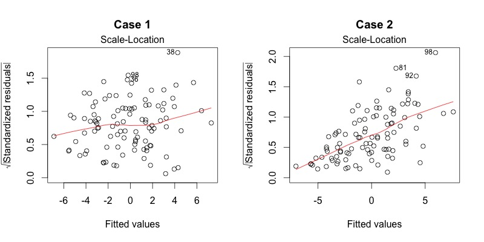

Scale-Location Plot

Lastly, the Residuals vs Leverage Plot helps to identify if there is influential case within the dataset, namely leverage. The dashed line will show the boundaries Cook’s distance, those cases located outside of dashed line are influential to the regression results. If we remove these cases, the regression model might be significantly changed.

Back to top

### Data Preparation

There are 2 datasets being used in this project. First - the KC_Housesales_Data from Kaggle and US Zip Codes Database retrieved from simplemaps.

```r
# import 2 datasets to be stored in 2 different dataframes
library(readr)
df_house <- read_csv("kc_house_data.csv")

library(readxl)
df_zipcode <- read_excel("uszips.xlsx")
```

```r
# KC_Housesales_Data
head(df_house)
```

```
## # A tibble: 6 x 21
##        id date   price bedrooms bathrooms sqft_living sqft_lot floors waterfront
##     <dbl> <chr>  <dbl>    <dbl>     <dbl>       <dbl>    <dbl>  <dbl>      <dbl>
## 1  7.13e9 10/1~ 2.22e5        3      1           1180     5650      1          0
## 2  6.41e9 12/9~ 5.38e5        3      2.25        2570     7242      2          0
## 3  5.63e9 2/25~ 1.80e5        2      1            770    10000      1          0
## 4  2.49e9 12/9~ 6.04e5        4      3           1960     5000      1          0
## 5  1.95e9 2/18~ 5.10e5        3      2           1680     8080      1          0
## 6  7.24e9 5/12~ 1.23e6        4      4.5         5420   101930      1          0
## # ... with 12 more variables: view <dbl>, condition <dbl>, grade <dbl>,
## #   sqft_above <dbl>, sqft_basement <dbl>, yr_built <dbl>, yr_renovated <dbl>,
## #   zipcode <dbl>, lat <dbl>, long <dbl>, sqft_living15 <dbl>, sqft_lot15 <dbl>
```

```r
colnames(df_house)
```

```
##  [1] "id"            "date"          "price"         "bedrooms"
##  [5] "bathrooms"     "sqft_living"   "sqft_lot"      "floors"
##  [9] "waterfront"    "view"          "condition"     "grade"
## [13] "sqft_above"    "sqft_basement" "yr_built"      "yr_renovated"
## [17] "zipcode"       "lat"           "long"          "sqft_living15"
## [21] "sqft_lot15"
```

```r
# US Zip Codes Database
head(df_zipcode)
```

```
## # A tibble: 6 x 18
##     zip   lat   lng city      state_id state_name  zcta  parent_zcta population
##   <dbl> <dbl> <dbl> <chr>     <chr>    <chr>       <chr> <lgl>            <dbl>
## 1   601  18.2 -66.8 Adjuntas  PR       Puerto Rico TRUE  NA               17113
## 2   602  18.4 -67.2 Aguada    PR       Puerto Rico TRUE  NA               37751
## 3   603  18.5 -67.1 Aguadilla PR       Puerto Rico TRUE  NA               47081
## 4   606  18.2 -66.9 Maricao   PR       Puerto Rico TRUE  NA                6392
## 5   610  18.3 -67.1 Anasco    PR       Puerto Rico TRUE  NA               26686
## 6   612  18.4 -66.7 Arecibo   PR       Puerto Rico TRUE  NA               59369
## # ... with 9 more variables: density <dbl>, county_fips <dbl>,
## #   county_name <chr>, county_weights <chr>, county_names_all <chr>,
## #   county_fips_all <chr>, imprecise <chr>, military <chr>, timezone <chr>
```

```r
colnames(df_zipcode)
```

```
##  [1] "zip"              "lat"              "lng"              "city"
##  [5] "state_id"         "state_name"       "zcta"             "parent_zcta"
##  [9] "population"       "density"          "county_fips"      "county_name"
## [13] "county_weights"   "county_names_all" "county_fips_all"  "imprecise"
## [17] "military"         "timezone"
```

#### Data Cleaning

**Data cleaning for df_house:**  
1. Remove unnecessary columns  
2. Transform some columns to categorical values  
3. Check for missing values

```r
## Removing the unnecessary information

df_house$id <- NULL
df_house$sqft_living <- NULL
df_house$sqft_lot <- NULL
df_house$view <- NULL
df_house$grade <- NULL
df_house$view <- NULL
df_house$sqft_above <- NULL
df_house$zip <- df_house$zipcode
df_house$zipcode <- NULL
df_house$lat <- NULL
df_house$long <- NULL

## Changing sqft_basement to basement (1 for yes and 0 for no)
df_house$basement <- df_house$sqft_basement
df_house$sqft_basement <- NULL
df_house$basement = ifelse(df_house$basement>0,"1","0")

## Changing yr_built to age
library("stringr")
df_house$date <- str_sub(df_house$date, - 4, - 1) #Extract the year from date of building sold
df_house$date <- as.numeric(df_house$date) #changing it to numeric for subtraction operation
df_house$age <- df_house$date - df_house$yr_built #age of building when sold is calculated
df_house$date <- NULL
df_house$yr_built <- NULL

## Changing yr_renovated to renovation (1 for yes and 0 for no)
df_house$renovation = ifelse(df_house$"yr_renovated">0,"1","0")
df_house$yr_renovated <- NULL

## Checking for missing values
sum(is.na(df_house))
```

```
## [1] 0
```

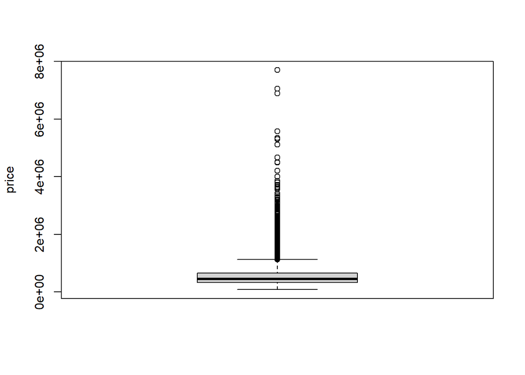

```r
## Saving new dataframe in csv
write.csv(df_house,'house_data.csv',row.names=FALSE)

# Detecting Outliers
boxplot(df_house$price, ylab = "price")
```

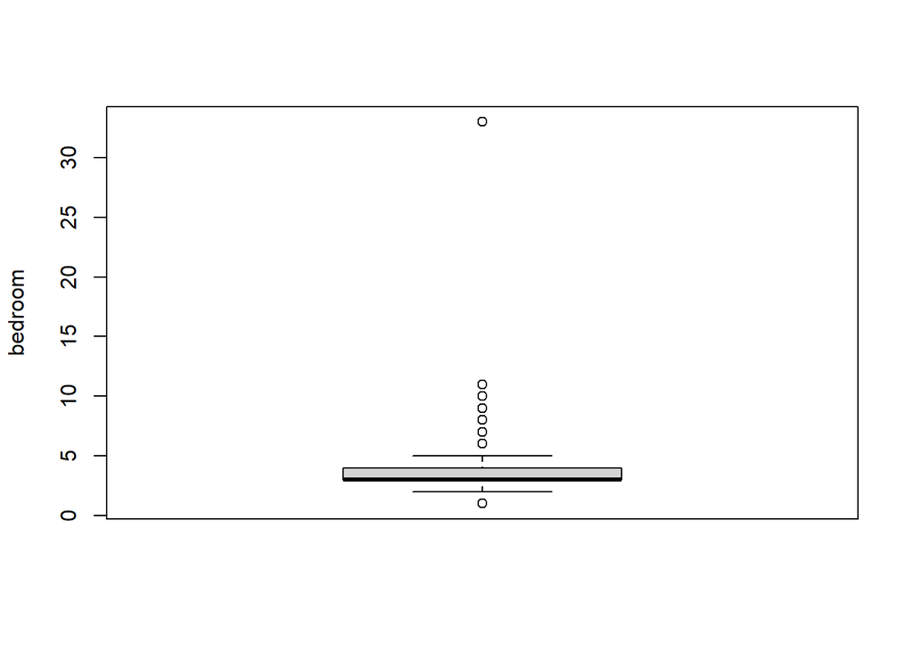

```r
boxplot(df_house$bedrooms, ylab = "bedroom")
```

```r
# reexamine the structure of the dataframe now
str(df_house)
```

```
## spec_tbl_df [21,597 x 12] (S3: spec_tbl_df/tbl_df/tbl/data.frame)
##  $ price        : num [1:21597] 221900 538000 180000 604000 510000 ...
##  $ bedrooms     : num [1:21597] 3 3 2 4 3 4 3 3 3 3 ...
##  $ bathrooms    : num [1:21597] 1 2.25 1 3 2 4.5 2.25 1.5 1 2.5 ...
##  $ floors       : num [1:21597] 1 2 1 1 1 1 2 1 1 2 ...
##  $ waterfront   : num [1:21597] 0 0 0 0 0 0 0 0 0 0 ...
##  $ condition    : num [1:21597] 3 3 3 5 3 3 3 3 3 3 ...
##  $ sqft_living15: num [1:21597] 1340 1690 2720 1360 1800 ...
##  $ sqft_lot15   : num [1:21597] 5650 7639 8062 5000 7503 ...
##  $ zip          : num [1:21597] 98178 98125 98028 98136 98074 ...
##  $ basement     : chr [1:21597] "0" "1" "0" "1" ...
##  $ age          : num [1:21597] 59 63 82 49 28 13 19 52 55 12 ...
##  $ renovation   : chr [1:21597] "0" "1" "0" "0" ...
##  - attr(*, "spec")=
##   .. cols(
##   ..   id = col_double(),
##   ..   date = col_character(),
##   ..   price = col_double(),
##   ..   bedrooms = col_double(),
##   ..   bathrooms = col_double(),
##   ..   sqft_living = col_double(),
##   ..   sqft_lot = col_double(),
##   ..   floors = col_double(),
##   ..   waterfront = col_double(),
##   ..   view = col_double(),
##   ..   condition = col_double(),
##   ..   grade = col_double(),
##   ..   sqft_above = col_double(),
##   ..   sqft_basement = col_double(),
##   ..   yr_built = col_double(),
##   ..   yr_renovated = col_double(),
##   ..   zipcode = col_double(),
##   ..   lat = col_double(),
##   ..   long = col_double(),
##   ..   sqft_living15 = col_double(),
##   ..   sqft_lot15 = col_double()
##   .. )
```

**Data cleaning for df_zipcode:**  
1. Remove unnecessary columns  
2. Remove duplicate rows using zipcode variable

```r
## Removing the unnecessary information
df_zipcode <- df_zipcode[ -c(2:3,5,7:18) ]

## Removing duplicate rows using the zipcode variable
library(dplyr)
df_zipcode %>% distinct(zip, .keep_all= TRUE)
```

```
## # A tibble: 33,121 x 3
##      zip city        state_name
##    <dbl> <chr>       <chr>
##  1   601 Adjuntas    Puerto Rico
##  2   602 Aguada      Puerto Rico
##  3   603 Aguadilla   Puerto Rico
##  4   606 Maricao     Puerto Rico
##  5   610 Anasco      Puerto Rico
##  6   612 Arecibo     Puerto Rico
##  7   616 Bajadero    Puerto Rico
##  8   617 Barceloneta Puerto Rico
##  9   622 Boqueron    Puerto Rico
## 10   623 Cabo Rojo   Puerto Rico
## # ... with 33,111 more rows
```

```r
write.csv(df_zipcode,'zipcode.csv',row.names=FALSE)
```

#### Data Merging

After we have cleaned the df_house and df_zipcode, now we can do data merging to merge the 2 dataframes as there are no city and state_name in the df_house.

```r
# Merging 2 datasets
df_house <- read_csv("house_data.csv")
df_zip <- read_csv("zipcode.csv")
df <- merge(df_house,df_zipcode,by="zip")

# Examine the frequency table of city and state_name
table(df$city)
```

```
##
##        Auburn      Bellevue Black Diamond       Bothell     Carnation
##           911          1407           100           195           124
##        Duvall      Enumclaw     Fall City   Federal Way      Issaquah
##           190           233            80           779           733
##       Kenmore          Kent      Kirkland  Maple Valley        Medina
##           283          1201           977           589            50
## Mercer Island    North Bend       Redmond        Renton     Sammamish
##           282           220           977          1597           800
##       Seattle    Snoqualmie        Vashon   Woodinville
##          8973           308           117           471
```

```r
table(df$state_name)
```

```
##
## Washington
##      21597
```

```r
# Since all state name is Washington, we can omit the state_name column
df$state_name <- NULL

# print the first few rows of the merged data
head(df, 10)
```

```
##      zip  price bedrooms bathrooms floors waterfront condition sqft_living15
## 1  98001 225000        3      1.00    1.0          0         3          1660
## 2  98001 210000        3      1.00    1.0          0         3          1820
## 3  98001 230000        3      1.00    1.0          0         4          1140
## 4  98001 196000        3      2.25    2.0          0         3          1890
## 5  98001 321500        4      2.50    2.0          0         3          2740
## 6  98001 360000        4      2.00    1.0          0         5          1230
## 7  98001 207000        3      1.00    1.0          0         4          1356
## 8  98001 420000        4      2.50    2.0          0         3          2990
## 9  98001 305000        2      1.00    1.5          0         4          1650
## 10 98001 429000        4      2.50    2.0          0         3          2730
##    sqft_lot15 basement age renovation   city
## 1        7245        1  51          0 Auburn
## 2        7210        1  51          0 Auburn
## 3        9639        0  48          0 Auburn
## 4        7519        0  40          0 Auburn
## 5        5816        0  11          0 Auburn
## 6       15750        0  49          0 Auburn
## 7        9450        1  71          0 Auburn
## 8        9033        0  13          0 Auburn
## 9       19200        0  79          0 Auburn
## 10       8688        0  13          0 Auburn
```

```r
str(df)
```

```
## 'data.frame':    21597 obs. of  13 variables:
##  $ zip          : num  98001 98001 98001 98001 98001 ...
##  $ price        : num  225000 210000 230000 196000 321500 ...
##  $ bedrooms     : num  3 3 3 3 4 4 3 4 2 4 ...
##  $ bathrooms    : num  1 1 1 2.25 2.5 2 1 2.5 1 2.5 ...
##  $ floors       : num  1 1 1 2 2 1 1 2 1.5 2 ...
##  $ waterfront   : num  0 0 0 0 0 0 0 0 0 0 ...
##  $ condition    : num  3 3 4 3 3 5 4 3 4 3 ...
##  $ sqft_living15: num  1660 1820 1140 1890 2740 ...
##  $ sqft_lot15   : num  7245 7210 9639 7519 5816 ...
##  $ basement     : num  1 1 0 0 0 0 1 0 0 0 ...
##  $ age          : num  51 51 48 40 11 49 71 13 79 13 ...
##  $ renovation   : num  0 0 0 0 0 0 0 0 0 0 ...
##  $ city         : chr  "Auburn" "Auburn" "Auburn" "Auburn" ...
```

```r
write.csv(df,'merged.csv',row.names=FALSE)
```

Back to top

### Data Analysis

#### Exploratory Data Analysis (EDA)

```r
## Rearranging the columns so that the price will be the first variable
df <- df[,c(2:12,1,13)]

## Viewing a Part of the Data
head(df,10)
```

```
##     price bedrooms bathrooms floors waterfront condition sqft_living15
## 1  225000        3      1.00    1.0          0         3          1660
## 2  210000        3      1.00    1.0          0         3          1820
## 3  230000        3      1.00    1.0          0         4          1140
## 4  196000        3      2.25    2.0          0         3          1890
## 5  321500        4      2.50    2.0          0         3          2740
## 6  360000        4      2.00    1.0          0         5          1230
## 7  207000        3      1.00    1.0          0         4          1356
## 8  420000        4      2.50    2.0          0         3          2990
## 9  305000        2      1.00    1.5          0         4          1650
## 10 429000        4      2.50    2.0          0         3          2730
##    sqft_lot15 basement age renovation   zip   city
## 1        7245        1  51          0 98001 Auburn
## 2        7210        1  51          0 98001 Auburn
## 3        9639        0  48          0 98001 Auburn
## 4        7519        0  40          0 98001 Auburn
## 5        5816        0  11          0 98001 Auburn
## 6       15750        0  49          0 98001 Auburn
## 7        9450        1  71          0 98001 Auburn
## 8        9033        0  13          0 98001 Auburn
## 9       19200        0  79          0 98001 Auburn
## 10       8688        0  13          0 98001 Auburn
```

```r
## Viewing the structure and summary statistics of the data
str(df)
```

```
## 'data.frame':    21597 obs. of  13 variables:
##  $ price        : num  225000 210000 230000 196000 321500 ...
##  $ bedrooms     : num  3 3 3 3 4 4 3 4 2 4 ...
##  $ bathrooms    : num  1 1 1 2.25 2.5 2 1 2.5 1 2.5 ...
##  $ floors       : num  1 1 1 2 2 1 1 2 1.5 2 ...
##  $ waterfront   : num  0 0 0 0 0 0 0 0 0 0 ...
##  $ condition    : num  3 3 4 3 3 5 4 3 4 3 ...
##  $ sqft_living15: num  1660 1820 1140 1890 2740 ...
##  $ sqft_lot15   : num  7245 7210 9639 7519 5816 ...
##  $ basement     : num  1 1 0 0 0 0 1 0 0 0 ...
##  $ age          : num  51 51 48 40 11 49 71 13 79 13 ...
##  $ renovation   : num  0 0 0 0 0 0 0 0 0 0 ...
##  $ zip          : num  98001 98001 98001 98001 98001 ...
##  $ city         : chr  "Auburn" "Auburn" "Auburn" "Auburn" ...
```

```r
summary(df)
```

```
##      price            bedrooms        bathrooms         floors
##  Min.   :  78000   Min.   : 1.000   Min.   :0.500   Min.   :1.000
##  1st Qu.: 322000   1st Qu.: 3.000   1st Qu.:1.750   1st Qu.:1.000
##  Median : 450000   Median : 3.000   Median :2.250   Median :1.500
##  Mean   : 540297   Mean   : 3.373   Mean   :2.116   Mean   :1.494
##  3rd Qu.: 645000   3rd Qu.: 4.000   3rd Qu.:2.500   3rd Qu.:2.000
##  Max.   :7700000   Max.   :33.000   Max.   :8.000   Max.   :3.500
##    waterfront         condition    sqft_living15    sqft_lot15
##  Min.   :0.000000   Min.   :1.00   Min.   : 399   Min.   :   651
##  1st Qu.:0.000000   1st Qu.:3.00   1st Qu.:1490   1st Qu.:  5100
##  Median :0.000000   Median :3.00   Median :1840   Median :  7620
##  Mean   :0.007547   Mean   :3.41   Mean   :1987   Mean   : 12758
##  3rd Qu.:0.000000   3rd Qu.:4.00   3rd Qu.:2360   3rd Qu.: 10083
##  Max.   :1.000000   Max.   :5.00   Max.   :6210   Max.   :871200
##     basement          age           renovation           zip
##  Min.   :0.000   Min.   : -1.00   Min.   :0.00000   Min.   :98001
##  1st Qu.:0.000   1st Qu.: 18.00   1st Qu.:0.00000   1st Qu.:98033
##  Median :0.000   Median : 40.00   Median :0.00000   Median :98065
##  Mean   :0.393   Mean   : 43.32   Mean   :0.04232   Mean   :98078
##  3rd Qu.:1.000   3rd Qu.: 63.00   3rd Qu.:0.00000   3rd Qu.:98118
##  Max.   :1.000   Max.   :115.00   Max.   :1.00000   Max.   :98199
##      city
##  Length:21597
##  Class :character
##  Mode  :character
##
##
##
```

```r
## Checking for the missing values in the data.
NA_values=data.frame(no_of_na_values=colSums(is.na(df)))
head(NA_values,13)
```

```
##               no_of_na_values
## price                       0
## bedrooms                    0
## bathrooms                   0
## floors                      0
## waterfront                  0
## condition                   0
## sqft_living15               0
## sqft_lot15                  0
## basement                    0
## age                         0
## renovation                  0
## zip                         0
## city                        0
```

```r
# Counting the number of groups with the same zip code and city
library(dplyr)
freq_zipcode <- as.data.frame(table(df$zip))
freq_zipcode <- freq_zipcode %>% rename(zipcode = Var1)
print(freq_zipcode)
```

```
##    zipcode Freq
## 1    98001  361
## 2    98002  199
## 3    98003  280
## 4    98004  317
## 5    98005  168
## 6    98006  498
## 7    98007  141
## 8    98008  283
## 9    98010  100
## 10   98011  195
## 11   98014  124
## 12   98019  190
## 13   98022  233
## 14   98023  499
```

[output cut: 56 more lines]

```r
freq_city <- as.data.frame(table(df$city))
freq_city <- freq_city %>% rename(city_name = Var1)
print(freq_city)
```

```
##        city_name Freq
## 1         Auburn  911
## 2       Bellevue 1407
## 3  Black Diamond  100
## 4        Bothell  195
## 5      Carnation  124
## 6         Duvall  190
## 7       Enumclaw  233
## 8      Fall City   80
## 9    Federal Way  779
## 10      Issaquah  733
## 11       Kenmore  283
## 12          Kent 1201
## 13      Kirkland  977
## 14  Maple Valley  589
## 15        Medina   50
## 16 Mercer Island  282
## 17    North Bend  220
## 18       Redmond  977
## 19        Renton 1597
## 20     Sammamish  800
## 21       Seattle 8973
## 22    Snoqualmie  308
## 23        Vashon  117
## 24   Woodinville  471
```

Dividing the data into Train and Test Data by using random sampling method. 70% of the data will be entering to train dataset whereas the rest will be test dataset. The reason of splitting dataset into two being to judge the performance of the prediction model on the test dataset afterwards.

```r
library(caTools)
```

```r
#  set seed to ensure you always have same random numbers generated
set.seed(123)

# splits the data in the ratio mentioned in SplitRatio. After splitting marks these rows as logical TRUE and the the remaining are marked as logical FALSE
sample = sample.split(df$zip,SplitRatio = 0.7)

# creates a training dataset named train_data with rows which are marked as TRUE
train_data =subset(df,sample ==TRUE)
test_data=subset(df, sample==FALSE)

# check the dimensions of train_data and test_data
dim(train_data)
```

```
## [1] 15116    13
```

```r
dim(test_data)
```

```
## [1] 6481   13
```

Determining the *association* between the variables.

```r
library(corrplot)
```

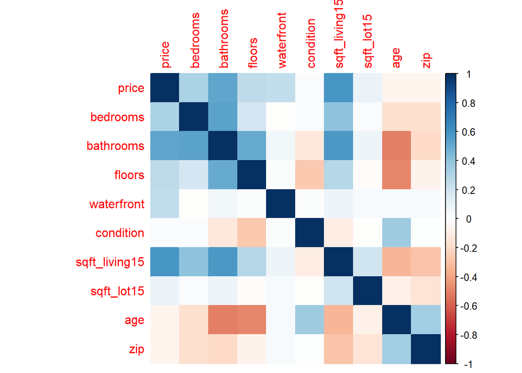

```r
cor_data=data.frame(train_data[,1:12])
cor_data = cor_data[, -c(9,11)]
correlation=cor(cor_data)
par(mfrow=c(1, 1))
corrplot(correlation,method="color")
```

According to our corrplot price is positively correlated with bedroom, bathroom, sqft_living15.  
Draw some *scatter plots* to determine the relationship between positive-correlated variables.

```r
library(ggplot2)
library(grid)
library(lattice)
library(gridExtra)
```

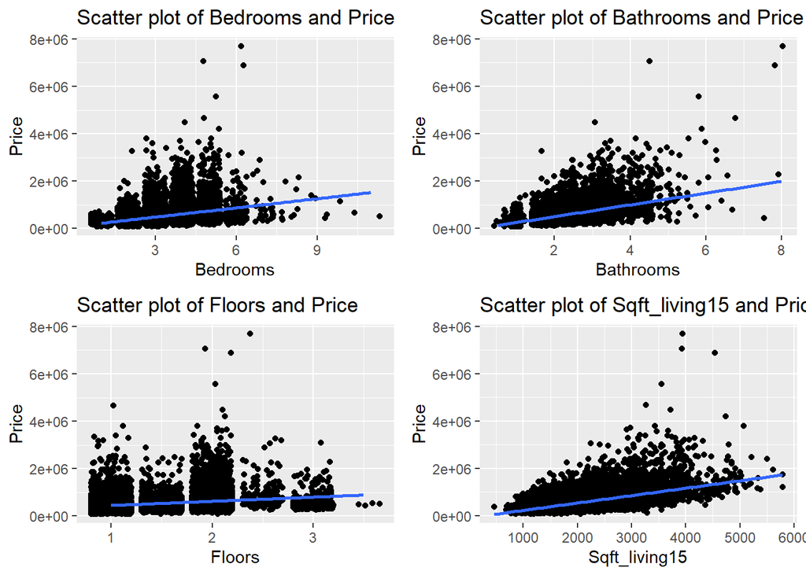

```r
p1=ggplot(data = train_data, aes(x = bedrooms, y = price)) +
  geom_jitter() +  geom_smooth(method = "lm", se = FALSE)+labs(title="Scatter plot of Bedrooms and Price", x="Bedrooms",y="Price")
p2=ggplot(data = train_data, aes(x = bathrooms, y = price)) +
  geom_jitter() +  geom_smooth(method = "lm", se = FALSE)+labs(title="Scatter plot of Bathrooms and Price", x="Bathrooms",y="Price")
p3=ggplot(data = train_data, aes(x = floors, y = price)) +
  geom_jitter() +  geom_smooth(method = "lm", se = FALSE)+labs(title="Scatter plot of Floors and Price", x="Floors",y="Price")
p4=ggplot(data = train_data, aes(x = sqft_living15, y = price)) +
  geom_jitter() +  geom_smooth(method = "lm", se = FALSE)+labs(title="Scatter plot of Sqft_living15 and Price", x="Sqft_living15",y="Price")

grid.arrange(p1,p2,p3,p4,nrow=2)
```

From these scatter plots, we can say that the relationship between price (dependent variable) and bedrooms, bathrooms and sqft_living15 (independent variables) are linear and in the positive direction. However, the relationship between price and floors is not obviously linear.  
The p-value from correlation test can be used to identify whether the correlation is significant.

```r
# create an empty list to store p-value of correlation test
p_value_df <- data.frame("Explanatory_Variable" = character(0), "p_value" = double(0), stringsAsFactors = FALSE)


for (i in 2:ncol(cor_data)) {
  p_value <- cor.test(cor_data[,1], cor_data[,i])$p.value
  new_row <- c(names(cor_data[i]), p_value)
  p_value_df[nrow(p_value_df)+1,] <- new_row
}

print(p_value_df)
```

```
##   Explanatory_Variable               p_value
## 1             bedrooms                     0
## 2            bathrooms                     0
## 3               floors  2.7422081672573e-228
## 4           waterfront 3.50284064304626e-201
## 5            condition   0.00100763267925831
## 6        sqft_living15                     0
## 7           sqft_lot15  8.00758800521312e-24
## 8                  age  1.14243642311684e-11
## 9                  zip  1.55392256300633e-11
```

Based on the p-value from correlation test between price and every single explanatory variable, the relationships seem all to be significant.  
For the 4 categorical variables(waterfront, basement, renovation and city) we draw *boxplots* to understand the relationships.

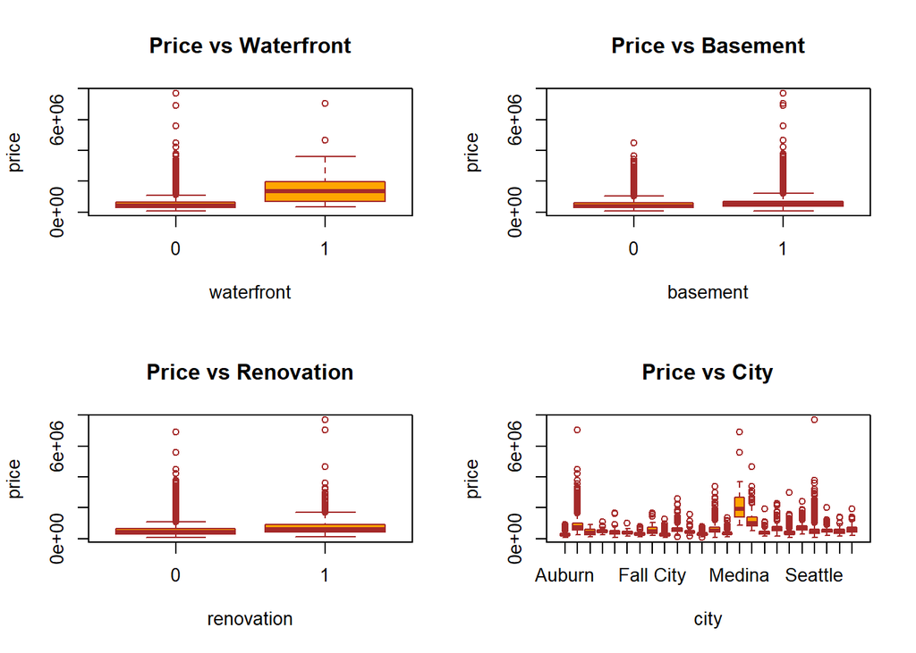

```r
par(mfrow=c(2, 2))
boxplot(price~waterfront,data=train_data,main="Price vs Waterfront", xlab="waterfront",ylab="price",col="orange",border="brown")
boxplot(price~basement,data=train_data,main="Price vs Basement", xlab="basement",ylab="price",col="orange",border="brown")
boxplot(price~renovation,data=train_data,main="Price vs Renovation", xlab="renovation",ylab="price",col="orange",border="brown")
boxplot(price~city,data=train_data,main="Price vs City", xlab="city",ylab="price",col="orange",border="brown")
```

There seem to have relationships between price with these 4 categorical variables.  
Checking for outliers in the dependent variable(price) using a boxplot.

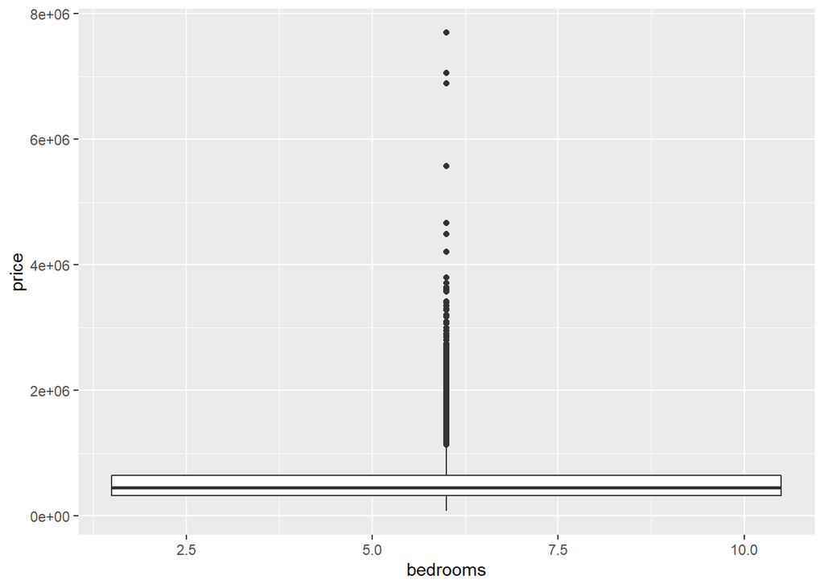

```r
ggplot(data=train_data)+geom_boxplot(aes(x=bedrooms,y=price))
```

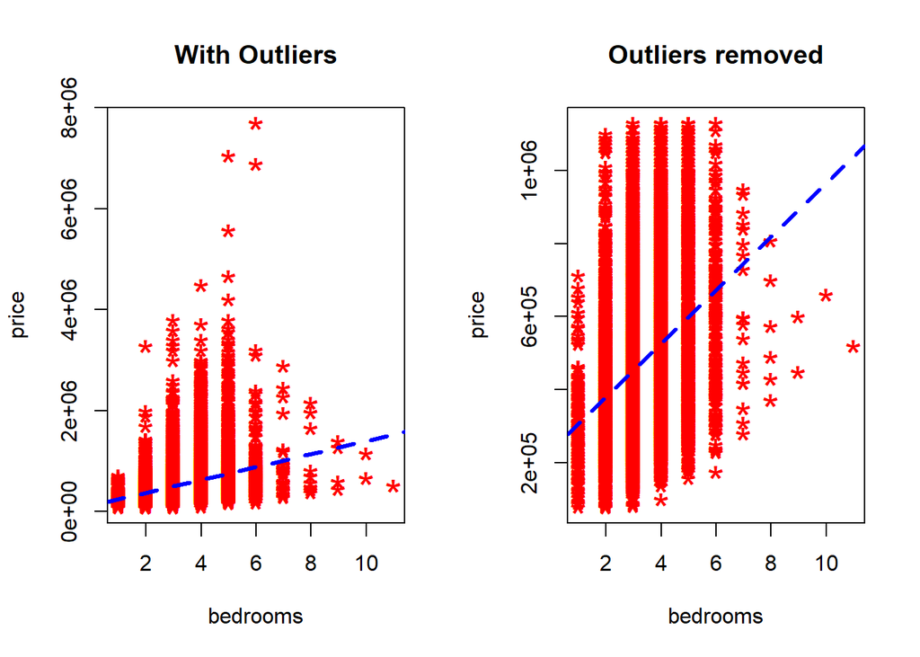

```r
outliers=boxplot(train_data$price,plot=FALSE)$out
outliers_data=train_data[which(train_data$price %in% outliers),]
train_data1= train_data[-which(train_data$price %in% outliers),]

par(mfrow=c(1, 2))
# Plot of original data without outliers.
plot(train_data$bedrooms, train_data$price, main="With Outliers", xlab="bedrooms", ylab="price", pch="*", col="red", cex=2)
abline(lm(price ~ bedrooms, data=train_data), col="blue", lwd=3, lty=2)

# Plot of data after removed outliers. Note the change of slope.
plot(train_data1$bedrooms, train_data1$price, main="Outliers removed", xlab="bedrooms", ylab="price", pch="*", col="red", cex=2)
abline(lm(price ~bedrooms, data=train_data1), col="blue", lwd=3, lty=2)
```

Back to top

#### Analysis of Variance (ANOVA)

##### Description

**Idendified Questions**

- Is there a significant difference in the house sold price based on the house variables?

**Objective**

- To investigate if the condition rate, renovation and city located affect house sold price.

In this section will focus on apply **One-way ANOVA** to find out if the categorical variables caused a difference in the mean of house sold price. The null hypothesis (H0) of the ANOVA is no difference in means, and the alternate hypothesis (H1) is that the means are different from one another. ANOVA assumes that each observation is randomly sampled, independent, normally distributed, and with unknown but equal variances.

ANOVA only reveals that are different between group means. Hence this section will also apply Tukey’s Honestly Significant Difference (Tukey’s HSD) test to tell which groups are statistically different from another.

**Steps:**

1. Analysis the factor level of the variable.
2. Perform ANOVA Test.
   - The ANOVA model summary lists the independent variable being tested in the model and the model residuals (The variation not explained by the independent variables is called residual variance.)
3. Perform Tukey’s HS Test.
4. Boxplot the price and variable to check the distribution.

Table below shows the variable that will be analysis. Not all of the variables from dataset were used in this analysis.

| Variable | Description | Level |
| --- | --- | --- |
| condition | How good the house condition is | 1 to 5 where 1=worst; 5=best |
| renovation | Indicate if the house has been renovated | 1=Yes; 0=NO |
| city | Indicate which city the house located | List of city name |

##### Packages & Dataset

**Loading Packages Library**

```r
library(ggplot2)
library(ggpubr)
library(gridExtra)
library(tidyverse)
library(broom)
library(AICcmodavg)
library(dplyr)
```

**Loading dataset**

```r
# Read the variables that will be analyse later as factor
house <- read.csv('merged.csv', header = TRUE, stringsAsFactors=T,
                  colClasses=c(rep('numeric', 6), 'factor', rep('numeric', 4),rep('factor', 2)))
glimpse(house)
```

```
## Rows: 21,597
## Columns: 13
## $ zip           <dbl> 98001, 98001, 98001, 98001, 98001, 98001, 98001, 98001, ~
## $ price         <dbl> 225000, 210000, 230000, 196000, 321500, 360000, 207000, ~
## $ bedrooms      <dbl> 3, 3, 3, 3, 4, 4, 3, 4, 2, 4, 4, 4, 5, 3, 4, 3, 3, 3, 3,~
## $ bathrooms     <dbl> 1.00, 1.00, 1.00, 2.25, 2.50, 2.00, 1.00, 2.50, 1.00, 2.~
## $ floors        <dbl> 1.0, 1.0, 1.0, 2.0, 2.0, 1.0, 1.0, 2.0, 1.5, 2.0, 1.0, 2~
## $ waterfront    <dbl> 0, 0, 0, 0, 0, 0, 0, 0, 0, 0, 0, 0, 0, 0, 0, 0, 0, 0, 0,~
## $ condition     <fct> 3, 3, 4, 3, 3, 5, 4, 3, 4, 3, 4, 3, 4, 4, 3, 3, 3, 4, 4,~
## $ sqft_living15 <dbl> 1660, 1820, 1140, 1890, 2740, 1230, 1356, 2990, 1650, 27~
## $ sqft_lot15    <dbl> 7245, 7210, 9639, 7519, 5816, 15750, 9450, 9033, 19200, ~
## $ basement      <dbl> 1, 1, 0, 0, 0, 0, 1, 0, 0, 0, 1, 0, 1, 0, 0, 0, 0, 0, 0,~
## $ age           <dbl> 51, 51, 48, 40, 11, 49, 71, 13, 79, 13, 37, 14, 59, 61, ~
## $ renovation    <fct> 0, 0, 0, 0, 0, 0, 0, 0, 0, 0, 0, 0, 0, 0, 0, 0, 0, 0, 0,~
## $ city          <fct> Auburn, Auburn, Auburn, Auburn, Auburn, Auburn, Auburn, ~
```

##### Price VS Condition

This section examine if there is a statistical difference between the mean of the house sold price according to the rate of condition given to the house.

**1.Overview of the `condition` variable**

```r
#Calculate frequency, mean and standard deviation
house %>%
  group_by(condition) %>%
  summarise(condition_freq = n(),
            price_mean = mean(price, na.rm = TRUE),
            price_sd = sd(price, na.rm = TRUE))
```

```
## # A tibble: 5 x 4
##   condition condition_freq price_mean price_sd
##   <fct>              <int>      <dbl>    <dbl>
## 1 1                     29    341067.  273483.
## 2 2                    170    328179.  246987.
## 3 3                  14020    542173.  364650.
## 4 4                   5677    521374.  358796.
## 5 5                   1701    612578.  411318.
```

**2.ANOVA Test**

Hypothesis:

- H0: The mean `price` is equal for all levels of `condition` categories.
- H1: At least one of the `condition` categories has a mean `price` that is not the same as the other `condition` categories.

The p-value of the `condition` variable is low (p < 0.001, indicated by the ’***’), which implies that rate of `condition` gives impact on the house sold `price`. Hence the H0 is rejected. There is a significant difference in the average price of house based on the condition of house.

```r
one_way <- aov(price ~ condition, data = house)
summary(one_way)
```

```
##                Df    Sum Sq   Mean Sq F value Pr(>F)
## condition       4 1.977e+13 4.942e+12   36.86 <2e-16 ***
## Residuals   21592 2.895e+15 1.341e+11
## ---
## Signif. codes:  0 '***' 0.001 '**' 0.01 '*' 0.05 '.' 0.1 ' ' 1
```

**3.Tukey test**

Base on the test results, there are statistically significant differences (p < 0.05) between condition groups 3-1 (3 and 1), 5-1, 3-2, 4-2, 5-2, 4-3, 5-3, 5-4. The difference between condition groups 2-1 and 4-1 are not statistically significant.

```r
TukeyHSD(one_way)
```

```
##   Tukey multiple comparisons of means
##     95% family-wise confidence level
##
## Fit: aov(formula = price ~ condition, data = house)
##
## $condition
##          diff         lwr        upr     p adj
## 2-1 -12888.48 -213572.104 187795.138 0.9997895
## 3-1 201105.82   15428.628 386783.004 0.0260297
## 4-1 180307.21   -5651.399 366265.817 0.0625225
## 5-1 271510.50   84450.580 458570.422 0.0007181
## 3-2 213994.30  136921.420 291067.177 0.0000000
## 4-2 193195.69  115447.286 270944.097 0.0000000
## 5-2 284398.98  204052.083 364745.884 0.0000000
## 4-3 -20798.61  -36512.198  -5085.016 0.0028281
## 5-3  70404.69   44758.500  96050.870 0.0000000
## 5-4  91203.29   63593.282 118813.303 0.0000000
```

**4.Boxplot of the distribution of `price` by `condition`:**

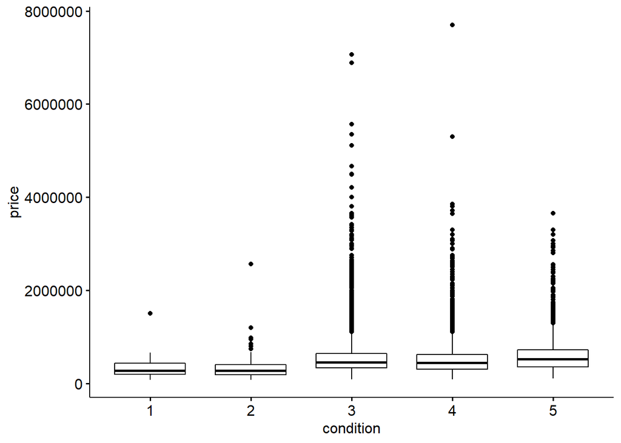

```r
options(scipen=999)
ggboxplot(house, x = "condition", y = "price", ylim=c(78000,7700000))
```

Back to top

##### Price VS Renovation

This section examine if there is a statistical difference between the mean of the house sold price and renovation state of the house.

**1.Overview of the `renovation` variable**

```r
#Calculate frequency, mean and standard deviation
house %>%
  group_by(renovation) %>%
  summarise(renovation_freq = n(),
            price_mean = mean(price, na.rm = TRUE),
            price_sd = sd(price, na.rm = TRUE))
```

```
## # A tibble: 2 x 4
##   renovation renovation_freq price_mean price_sd
##   <fct>                <int>      <dbl>    <dbl>
## 1 0                    20683    530560.  349805.
## 2 1                      914    760629.  608017.
```

**2.ANOVA Test**

Hypothesis:

- H0: The mean `price` is equal for all levels of `renovation` categories.
- H1: At least one of the `renovation` categories has a mean `price` that is not the same as the other `renovation` categories.

The p-value of the `renovation` variable is low (p < 0.001, indicated by the ’***’), which implies that state of `renovation` gives impact on the house sold `price`. Hence the H0 is rejected. There is a significant difference in the average price of house based on the renovation state of the house.

```r
one_way <- aov(price ~ renovation, data = house)
summary(one_way)
```

```
##                Df           Sum Sq        Mean Sq F value              Pr(>F)
## renovation      1   46332107051977 46332107051977   348.8 <0.0000000000000002
## Residuals   21595 2868250023356214   132820098326
##
## renovation  ***
## Residuals
## ---
## Signif. codes:  0 '***' 0.001 '**' 0.01 '*' 0.05 '.' 0.1 ' ' 1
```

**3.Tukey test**

Base on the test results, there are statistically significant differences (p < 0.05) between renovation group 1 and 0.

```r
TukeyHSD(one_way)
```

```
##   Tukey multiple comparisons of means
##     95% family-wise confidence level
##
## Fit: aov(formula = price ~ renovation, data = house)
##
## $renovation
##         diff      lwr      upr p adj
## 1-0 230068.9 205924.2 254213.5     0
```

**4.Boxplot of the distribution of `price` by `renovation`:**

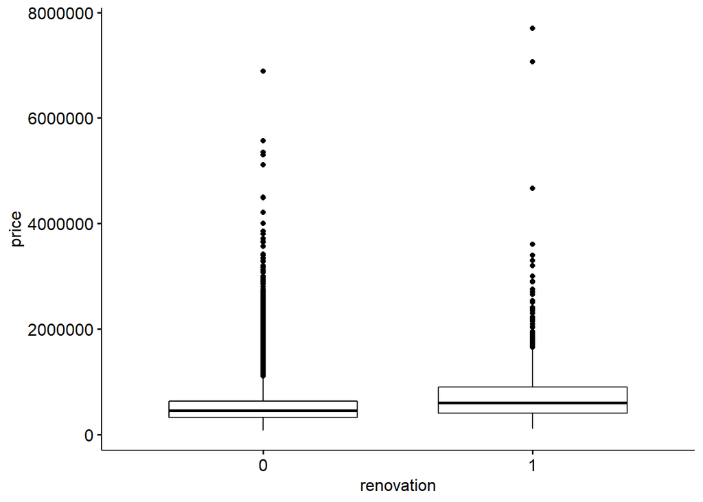

```r
options(scipen=999)
ggboxplot(house, x = "renovation", y = "price", ylim=c(78000,7700000))
```

Back to top

##### Price vs City

This section examine if there is a statistical difference between the mean of the house sold price according to the location of city of the house.

**1.Overview of the `city` variable**

```r
#Calculate frequency, mean and standard deviation
options(dplyr.print_max = 1e9)
house %>%
  group_by(city) %>%
  summarise(city_freq = n(),
            price_mean = mean(price, na.rm = TRUE),
            price_sd = sd(price, na.rm = TRUE))
```

```
## # A tibble: 24 x 4
##    city          city_freq price_mean price_sd
##    <fct>             <int>      <dbl>    <dbl>
##  1 Auburn              911    291648.  108422.
##  2 Bellevue           1407    898466.  559782.
##  3 Black Diamond       100    423666.  195415.
##  4 Bothell             195    490377.  121971.
##  5 Carnation           124    455617.  258603.
##  6 Duvall              190    424815.  130638.
##  7 Enumclaw            233    316742.  122329.
##  8 Fall City            80    586121.  376719.
##  9 Federal Way         779    289391.  108399.
## 10 Issaquah            733    615122.  260451.
## 11 Kenmore             283    462489.  149530.
## 12 Kent               1201    299470.   91647.
## 13 Kirkland            977    646543.  409633.
## 14 Maple Valley        589    367091.  132721.
## 15 Medina               50   2161300  1166904.
## 16 Mercer Island       282   1194874.  607768.
## 17 North Bend          220    440232.  207554.
## 18 Redmond             977    658432.  231136.
## 19 Renton             1597    403468.  200725.
## 20 Sammamish           800    732821.  280951.
## 21 Seattle            8973    535086.  340519.
## 22 Snoqualmie          308    529630.  185254.
## 23 Vashon              117    489382.  201501.
## 24 Woodinville         471    617498.  244298.
```

**2.ANOVA Test**

Hypothesis:

- H0: The mean `price` is equal for all levels of `city` categories.
- H1: At least one of the `city` categories has a mean `price` that is not the same as the other `city` categories.

The p-value of the `city` variable is low (p < 0.001, indicated by the ’***’), which implies that location of `city` gives impact on the house sold `price`. Hence the H0 is rejected. There is a significant difference in the average price of house based on the location of house.

```r
one_way <- aov(price ~ city, data = house)
summary(one_way)
```

```
##                Df           Sum Sq        Mean Sq F value              Pr(>F)
## city           23  738104329040975 32091492566999   318.1 <0.0000000000000002
## Residuals   21573 2176477801366934   100888972390
##
## city        ***
## Residuals
## ---
## Signif. codes:  0 '***' 0.001 '**' 0.01 '*' 0.05 '.' 0.1 ' ' 1
```

**3.Tukey test**

There are statistically significant differences between `city` groups with p < 0.05.

```r
TukeyHSD(one_way)
```

```
##   Tukey multiple comparisons of means
##     95% family-wise confidence level
##
## Fit: aov(formula = price ~ city, data = house)
##
## $city
##                                      diff          lwr           upr     p adj
## Bellevue-Auburn               606818.2632   557681.911   655954.6152 0.0000000
## Black Diamond-Auburn          132018.1700    10296.242   253740.0976 0.0167217
## Bothell-Auburn                198729.2877   107558.963   289899.6123 0.0000000
## Carnation-Auburn              163969.2929    53369.943   274568.6432 0.0000187
## Duvall-Auburn                 133167.2432    41014.111   225320.3756 0.0000393
## Enumclaw-Auburn                25094.5706   -59731.294   109920.4352 0.9999950
## Fall City-Auburn              294473.0550   159736.612   429209.4977 0.0000000
## Federal Way-Auburn             -2256.5222   -58642.078    54129.0338 1.0000000
## Issaquah-Auburn               323474.3533   266143.004   380805.7025 0.0000000
## Kenmore-Auburn                170841.0493    92208.530   249473.5683 0.0000000
## Kent-Auburn                     7822.2275   -42943.276    58587.7308 1.0000000
## Kirkland-Auburn               354895.0070   301678.428   408111.5865 0.0000000
## Maple Valley-Auburn            75443.6639    14352.102   136535.2253 0.0017262
## Medina-Auburn                1869652.1800  1701822.049  2037482.3115 0.0000000
## Mercer Island-Auburn          903225.8183   824486.997   981964.6399 0.0000000
## North Bend-Auburn             148584.4937    61785.797   235383.1906 0.0000000
## Redmond-Auburn                366783.9559   313567.376   420000.5353 0.0000000
## Renton-Auburn                 111820.6409    63846.793   159794.4885 0.0000000
## Sammamish-Auburn              441173.1875   385187.985   497158.3902 0.0000000
## Seattle-Auburn                243437.7799   203259.552   283616.0078 0.0000000
## Snoqualmie-Auburn             237981.9625   161823.225   314140.7003 0.0000000
## Vashon-Auburn                 197734.1971    84260.065   311208.3292 0.0000000
## Woodinville-Auburn            325850.0505   260275.275   391424.8258 0.0000000
## Black Diamond-Bellevue       -474800.0932  -594381.046  -355219.1404 0.0000000
## Bothell-Bellevue             -408088.9755  -496380.565  -319797.3864 0.0000000
## Carnation-Bellevue           -442848.9703  -551087.563  -334610.3779 0.0000000
## Duvall-Bellevue              -473651.0200  -562957.103  -384344.9372 0.0000000
## Enumclaw-Bellevue            -581723.6926  -663447.642  -499999.7431 0.0000000
## Fall City-Bellevue           -312345.2082  -445150.651  -179539.7655 0.0000000
## Federal Way-Bellevue         -609074.7853  -660676.215  -557473.3558 0.0000000
## Issaquah-Bellevue            -283343.9099  -335977.171  -230710.6484 0.0000000
## Kenmore-Bellevue             -435977.2139  -511253.038  -360701.3900 0.0000000
## Kent-Bellevue                -598996.0357  -644388.909  -553603.1625 0.0000000
```

[output cut: 228 more lines]

```
## Sammamish-Renton              329352.5466   279304.285   379400.8082 0.0000000
## Seattle-Renton                131617.1390   100236.005   162998.2731 0.0000000
## Snoqualmie-Renton             126161.3216    54254.167   198068.4765 0.0000000
## Vashon-Renton                  85913.5562   -24751.995   196579.1075 0.4183959
## Woodinville-Renton            214029.4096   153444.455   274614.3643 0.0000000
## Seattle-Sammamish            -197735.4076  -240369.061  -155101.7538 0.0000000
## Snoqualmie-Sammamish         -203191.2250  -280673.428  -125709.0220 0.0000000
## Vashon-Sammamish             -243438.9904  -357805.581  -129072.3996 0.0000000
## Woodinville-Sammamish        -115323.1370  -182430.436   -48215.8379 0.0000000
## Snoqualmie-Seattle             -5455.8174   -72414.304    61502.6687 1.0000000
## Vashon-Seattle                -45703.5828  -153219.462    61812.2959 0.9978584
## Woodinville-Seattle            82412.2706    27792.341   137032.1999 0.0000109
## Vashon-Snoqualmie             -40247.7654  -165728.949    85233.4185 0.9999781
## Woodinville-Snoqualmie         87868.0880     3196.959   172539.2166 0.0312061
## Woodinville-Vashon            128115.8534     8761.652   247470.0545 0.0194816
```

**4.Boxplot of the distribution of `price` by `city`:**

Note that y-axis represents `city` and x-axis represent `price`.

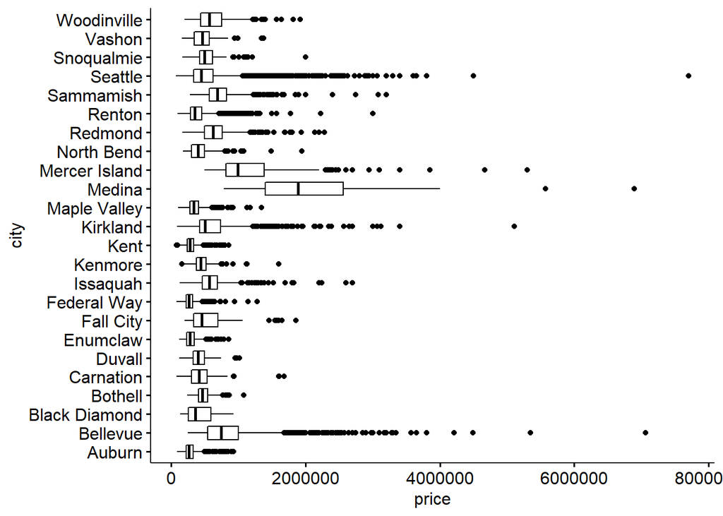

```r
options(scipen=999)
p <- ggboxplot(house, x = "city", y = "price", ylim=c(78000,7700000))
p + coord_flip()
```

Back to top

#### Multiple Linear Regression (MLR)

##### Description

**Idendified Questions**

- Can we predict the house price with the given attributes of each record of house sold?

**Objective**

- To predict the future house price with at least 70% of accuracy.

Multiple linear regression will be conducted to get a prediction model on the house price based on the selected variables `{bedrooms+bathrooms+floors+waterfront+condition+sqft_living15+sqft_lot15+basement+age+renovation}`. We will apply the machine learning algorithm on the multiple linear regression analysis.

**Steps:**

1. Construct a linear model
2. Influential points detection
   - Remove outliers but keep the influential points for further analysis
3. Regression diagnostics - check on assumptions validity
4. Prediction of house price - check on the accuracy of the model

##### Model Fitting

```r
library(tidyverse)
library(caret)
library(leaps)
library(MASS)
```

```r
# Fit the full model
full.model <- lm(price~bedrooms+bathrooms+floors+waterfront+condition+sqft_living15+sqft_lot15+basement+age+renovation,
             data=train_data)

summary(full.model)
```

```
##
## Call:
## lm(formula = price ~ bedrooms + bathrooms + floors + waterfront +
##     condition + sqft_living15 + sqft_lot15 + basement + age +
##     renovation, data = train_data)
##
## Residuals:
##      Min       1Q   Median       3Q      Max
## -1368535  -138479   -19711    95065  5359381
##
## Coefficients:
##                    Estimate    Std. Error t value             Pr(>|t|)
## (Intercept)   -618913.05670   16392.28963 -37.756 < 0.0000000000000002 ***
## bedrooms       -16207.19033    2800.96325  -5.786        0.00000000734 ***
## bathrooms      162750.13651    4511.18320  36.077 < 0.0000000000000002 ***
## floors          87845.32218    5069.17522  17.329 < 0.0000000000000002 ***
## waterfront     714137.93994   24169.48956  29.547 < 0.0000000000000002 ***
## condition       20575.69979    3507.33209   5.866        0.00000000454 ***
## sqft_living15     241.66378       3.81982  63.266 < 0.0000000000000002 ***
## sqft_lot15         -0.15926       0.08052  -1.978                0.048 *
## basement        64369.36922    4784.86699  13.453 < 0.0000000000000002 ***
## age              3585.34355      98.54000  36.385 < 0.0000000000000002 ***
## renovation      64859.42790   10974.10387   5.910        0.00000000349 ***
## ---
## Signif. codes:  0 '***' 0.001 '**' 0.01 '*' 0.05 '.' 0.1 ' ' 1
##
## Residual standard error: 255000 on 15105 degrees of freedom
## Multiple R-squared:  0.5136, Adjusted R-squared:  0.5132
## F-statistic:  1595 on 10 and 15105 DF,  p-value: < 0.00000000000000022
```

```r
# stepwise regression
fit <- lm(price~bedrooms+bathrooms+floors+waterfront+condition+sqft_living15+sqft_lot15+basement+age+renovation,
             data=train_data)
step <- stepAIC(fit, direction="both")
```

```
## Start:  AIC=376374.2
## price ~ bedrooms + bathrooms + floors + waterfront + condition +
##     sqft_living15 + sqft_lot15 + basement + age + renovation
##
##                 Df       Sum of Sq              RSS    AIC
## <none>                              982495104508443 376374
## - sqft_lot15     1    254430333018  982749534841461 376376
## - bedrooms       1   2177761472192  984672865980634 376406
## - condition      1   2238541329829  984733645838272 376407
## - renovation     1   2272049345704  984767153854146 376407
## - basement       1  11771408551175  994266513059617 376552
## - floors         1  19533152418298 1002028256926740 376670
## - waterfront     1  56785691806884 1039280796315327 377222
## - bathrooms      1  84658673487397 1067153777995840 377622
## - age            1  86108511845013 1068603616353456 377642
## - sqft_living15  1 260343083778339 1242838188286782 379925
```

```r
step$anova
```

```
## Stepwise Model Path
## Analysis of Deviance Table
##
## Initial Model:
## price ~ bedrooms + bathrooms + floors + waterfront + condition +
##     sqft_living15 + sqft_lot15 + basement + age + renovation
##
## Final Model:
## price ~ bedrooms + bathrooms + floors + waterfront + condition +
##     sqft_living15 + sqft_lot15 + basement + age + renovation
##
##
##   Step Df Deviance Resid. Df      Resid. Dev      AIC
## 1                      15105 982495104508443 376374.2
```

The full model of multiple linear regression model is significant with 0.513567007867493 as the R-squared value. The relationships between these variables with price are considered strong with all significant p-values. Stepwise regression also shows that all variables should be retained in the model. We may try to remove *sqft_lot15* from the model as the p-value at 0.048 is relatively higher compared to other variables.

```r
lm1 <- lm(price~bedrooms+bathrooms+floors+waterfront+condition+sqft_living15+basement+age+renovation,
             data=train_data)

summary(lm1)
```

```
##
## Call:
## lm(formula = price ~ bedrooms + bathrooms + floors + waterfront +
##     condition + sqft_living15 + basement + age + renovation,
##     data = train_data)
##
## Residuals:
##      Min       1Q   Median       3Q      Max
## -1371691  -138588   -19819    95116  5361376
##
## Coefficients:
##                  Estimate  Std. Error t value             Pr(>|t|)
## (Intercept)   -620294.448   16378.981 -37.871 < 0.0000000000000002 ***
## bedrooms       -15984.071    2798.960  -5.711        0.00000001146 ***
## bathrooms      162635.627    4511.246  36.051 < 0.0000000000000002 ***
## floors          88748.241    5049.062  17.577 < 0.0000000000000002 ***
## waterfront     713133.505   24166.482  29.509 < 0.0000000000000002 ***
## condition       20466.362    3507.234   5.835        0.00000000547 ***
## sqft_living15     240.318       3.759  63.930 < 0.0000000000000002 ***
## basement        65000.082    4774.688  13.613 < 0.0000000000000002 ***
## age              3592.837      98.477  36.484 < 0.0000000000000002 ***
## renovation      64493.689   10973.603   5.877        0.00000000426 ***
## ---
## Signif. codes:  0 '***' 0.001 '**' 0.01 '*' 0.05 '.' 0.1 ' ' 1
##
## Residual standard error: 255100 on 15106 degrees of freedom
## Multiple R-squared:  0.5134, Adjusted R-squared:  0.5132
## F-statistic:  1771 on 9 and 15106 DF,  p-value: < 0.00000000000000022
```

Since the adjusted R-squared still the same, we may continue with the model without sqft_lot15. Now, we try to train the model using `caret` package.

```r
# train the model
train.model <- train(price~bedrooms+bathrooms+floors+waterfront+condition+sqft_living15+basement+age+renovation,
             data=train_data, method="lm")

summary(train.model)
```

```
##
## Call:
## lm(formula = .outcome ~ ., data = dat)
##
## Residuals:
##      Min       1Q   Median       3Q      Max
## -1371691  -138588   -19819    95116  5361376
##
## Coefficients:
##                  Estimate  Std. Error t value             Pr(>|t|)
## (Intercept)   -620294.448   16378.981 -37.871 < 0.0000000000000002 ***
## bedrooms       -15984.071    2798.960  -5.711        0.00000001146 ***
## bathrooms      162635.627    4511.246  36.051 < 0.0000000000000002 ***
## floors          88748.241    5049.062  17.577 < 0.0000000000000002 ***
## waterfront     713133.505   24166.482  29.509 < 0.0000000000000002 ***
## condition       20466.362    3507.234   5.835        0.00000000547 ***
## sqft_living15     240.318       3.759  63.930 < 0.0000000000000002 ***
## basement        65000.082    4774.688  13.613 < 0.0000000000000002 ***
## age              3592.837      98.477  36.484 < 0.0000000000000002 ***
## renovation      64493.689   10973.603   5.877        0.00000000426 ***
## ---
## Signif. codes:  0 '***' 0.001 '**' 0.01 '*' 0.05 '.' 0.1 ' ' 1
##
## Residual standard error: 255100 on 15106 degrees of freedom
## Multiple R-squared:  0.5134, Adjusted R-squared:  0.5132
## F-statistic:  1771 on 9 and 15106 DF,  p-value: < 0.00000000000000022
```

```r
# display the R-squared value
train.model_rsq <- summary(train.model$finalModel)$r.squared

# show the bootstrap results
train.model
```

```
## Linear Regression
##
## 15116 samples
##     9 predictor
##
## No pre-processing
## Resampling: Bootstrapped (25 reps)
## Summary of sample sizes: 15116, 15116, 15116, 15116, 15116, 15116, ...
## Resampling results:
##
##   RMSE      Rsquared  MAE
##   255794.3  0.516118  162309.8
##
## Tuning parameter 'intercept' was held constant at a value of TRUE
```

```r
# store the results of bootstrap in a dataframe
train.model_results <- as.data.frame(train.model$results)
```

Back to top

##### Influential Points Detection

Cook’s distance can be used to detect the **influential points** in the model.

```r
cooksd <- cooks.distance(lm1)
cat("The mean of Cook's distance is ", mean(cooksd))
```

```
## The mean of Cook's distance is  0.0002049408
```

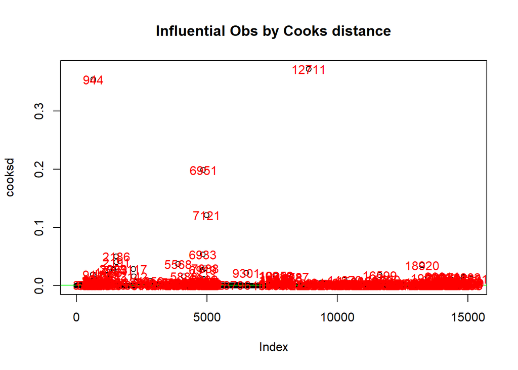

```r
# visualize the Cook's distance in a plot
# par(mfrow=c(1, 1))
# plot(cooksd, main="Influential Obs by Cooks distance",xlim=c(0,25000),ylim=c(0,0.1))
# axis(1, at=seq(0, 25000, 5000))
# axis(2, at=seq(0, 0.1, 0.0001))
# abline(h = 4*mean(cooksd, na.rm=T), col="green")
# text(x=1:length(cooksd)+1,y=cooksd,labels=ifelse(cooksd>4*mean(cooksd,na.rm=T),names(cooksd),""), col="red")

par(mfrow=c(1, 1))
plot(cooksd, main="Influential Obs by Cooks distance")
abline(h = 4*mean(cooksd, na.rm=T), col="green")
text(x=1:length(cooksd)+1,y=cooksd,labels=ifelse(cooksd>4*mean(cooksd,na.rm=T),names(cooksd),""), col="red")
```

Identify the position of influential points in the data.

```r
# any point that have Cook's distance greater than 4 times of mean will be considered as influential
influential <- as.numeric(names(cooksd)[(cooksd > 4*mean(cooksd, na.rm=T))])

# influential row numbers
head(train_data[influential, ])
```

```
##        price bedrooms bathrooms floors waterfront condition sqft_living15
## 533   200000        3      2.25    1.5          0         5          1260
## 802   225900        3      1.00    1.0          0         4          1290
## 1009  625000        3      2.00    1.0          0         4          2470
## 1189  790000        5      3.25    1.0          0         4          2590
## 1213 1000000        5      2.50    2.0          0         4          3600
## 1222  596000        3      2.50    2.0          0         3          1730
##      sqft_lot15 basement age renovation   zip        city
## 533        7556        0 101          0 98002      Auburn
## 802        8470        1  52          0 98003 Federal Way
## 1009      13594        0  28          0 98004    Bellevue
## 1189      12160        1  47          0 98005    Bellevue
## 1213      48787        0  46          0 98005    Bellevue
## 1222       2751        0  14          0 98005    Bellevue
```

```r
influential_data <- train_data[influential, ]
```

```r
# inner join outliers_data and influential_data
influential_outliers <- inner_join(outliers_data,influential_data)

# remove outliers_data from train_data but keep the influential_data
train_data2 <- rbind(train_data1,influential_outliers)

# relabel the index of train_data2
row.names(train_data2) <- NULL
```

There are 13 outliers yet influential observations in the train data. The outliers_data is removed but influential_outliers should be kept. Remodel the data by using `train_data2`.

```r
lm2 <- lm(price~bedrooms+bathrooms+floors+waterfront+condition+sqft_living15+basement+age+renovation,
             data=train_data2)

summary(lm2)
```

```
##
## Call:
## lm(formula = price ~ bedrooms + bathrooms + floors + waterfront +
##     condition + sqft_living15 + basement + age + renovation,
##     data = train_data2)
##
## Residuals:
##     Min      1Q  Median      3Q     Max
## -627995 -105915  -11026   90600 1287030
##
## Coefficients:
##                  Estimate  Std. Error t value             Pr(>|t|)
## (Intercept)   -318110.996   10613.765 -29.972 < 0.0000000000000002 ***
## bedrooms        -4680.359    1754.009  -2.668              0.00763 **
## bathrooms       72914.349    2961.479  24.621 < 0.0000000000000002 ***
## floors          93313.267    3194.663  29.209 < 0.0000000000000002 ***
## waterfront     145556.462   22601.758   6.440       0.000000000123 ***
## condition       19991.399    2182.831   9.158 < 0.0000000000000002 ***
## sqft_living15     171.916       2.522  68.173 < 0.0000000000000002 ***
## basement        61381.203    2986.837  20.551 < 0.0000000000000002 ***
## age              2311.441      63.029  36.673 < 0.0000000000000002 ***
## renovation      29232.066    7206.310   4.056       0.000050087351 ***
## ---
## Signif. codes:  0 '***' 0.001 '**' 0.01 '*' 0.05 '.' 0.1 ' ' 1
##
## Residual standard error: 154100 on 14323 degrees of freedom
## Multiple R-squared:  0.4693, Adjusted R-squared:  0.469
## F-statistic:  1407 on 9 and 14323 DF,  p-value: < 0.00000000000000022
```

The Residual Standard Error decreased as compared to the model with outliers_data. The model with revised data is significant with all the variables strongly related to price.

Back to top

##### Regression Diagnostics

The assumptions of the model need to be checked.

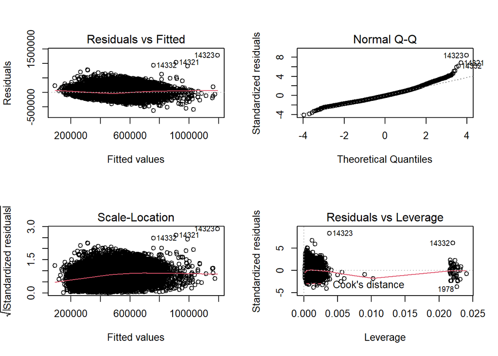

```r
# Residual diagnostics with the 4 plot
par(mfrow = c(2, 2))
plot(lm2)
```

##### Multicollinearity Test

Multicollinearity can be checked with multiple ways, one of the methods is by checking the Variance Inflation Factor (VIF). If the VIF value is greater than 4, there is investigation needed. If VIF above 10, it indicated there are serious multicollinearity between the predictors.

```r
library(car)
vif(lm2)
```

```
##      bedrooms     bathrooms        floors    waterfront     condition
##      1.445350      2.721895      1.762581      1.007715      1.203717
## sqft_living15      basement           age    renovation
##      1.480062      1.272886      2.029259      1.136379
```

There is no multicollinearity in the model.

##### Accuracy of the Model on Prediction

**Prediction on Train Data**

```r
# fitted values of train data
pred=lm2$fitted.values

# store the actual price and fitted price in a data frame
actual_fitted=data.frame(actual=train_data2$price, predicted=pred)

# find the mean of absolute difference % between fitted values and actual values
abs_diff = mean(abs(actual_fitted$actual-actual_fitted$predicted)/actual_fitted$actual)

# accuracy of the model
accuracy=1-abs_diff
accuracy
```

```
## [1] 0.7045188
```

The accuracy of the model on train data is **70.45%**.

**Prediction on Test Data**

```r
# use the model to predict price for test data
pred_test=predict(newdata=test_data, lm2)

# store the actual price and predicted price in a data frame
actual_fitted_test=data.frame(actual=test_data$price, predicted=pred_test)

# find the mean of absolute difference % between predicted values and actual values
abs_diff_test = mean(abs(actual_fitted_test$actual-actual_fitted_test$predicted)/actual_fitted_test$actual)

# accuracy of the prediction
accuracy=1-abs_diff_test
accuracy
```

```
## [1] 0.6929814
```

The accuracy of the prediction is at **69.3%**.

### Conclusion

The analysis was conducted by using the house price dataset from Kaggle, contains data for houses located in the state of Washington. The results from **One-way ANOVA test** show that there is significant difference on the average house price among houses with different *conditions*. Besides, a *renovated* house tends to have a different mean price as compared to a non-renovated house. There are multiple cities in the state of Washington, the dataset contained house price records from 24 cities. The One-way ANOVA test shows that there is significant difference in the average house price at different *cities*. Hence, these 3 variables would be significant factors in deciding the selling price of a house.  
The **multiple linear regression** model shows that `bedrooms`, `bathrooms`, `floors`, `waterfront`, `condition`, `sqft_living15`, `basement`, `age`, `renovation` are significant factors that affecting the house price. The prediction model able to predict the house price in Washington state by taking into account the 9 variables above at approximately 70% of accuracy.  
Further analysis can be done:  
1. perform non-linear regression  
2. perform robust regression